# Compile and Clean Dendro Data

Carmen

December 11, 2018

# Load clean detailed data

```r
setwd("~/Shrubs-Seedlings/code/GrowthMortality_Analysis/")
load("../../compiled_data/growth_mortality/df_detailed_clean.Rdata")
df_full <- df
remove(df)
load("../../compiled_data/dendro_joined.Rdata")
load("../../compiled_data/rwl_joined.Rdata")
```

# Take out replicate Seedling 12 - the correct seedling 12 is on Board 43, wrong one is on 45

```r
df %>% filter(series %in% c("12R1", "12R2", "12R3"))
```

```
##   series  board 2004 2005 2006 2007 2008 2009 2010 2011 2012 2013 2014
## 1   12R1 P2Bd43   NA   NA   NA   NA   NA   NA 0.47 0.36 0.33 0.34 0.31
## 2   12R2 P2Bd43   NA   NA   NA   NA   NA   NA 0.43 0.38 0.23 0.27 0.28
## 3   12R3 P2Bd43   NA   NA   NA   NA   NA   NA 0.51 0.49 0.57 0.38 0.52
## 4   12R1 P1Bd45   NA   NA   NA   NA   NA   NA   NA   NA 0.36 0.45 0.44
## 5   12R2 P1Bd45   NA   NA   NA   NA   NA   NA   NA   NA 0.40 0.64 0.49
## 6   12R3 P1Bd45   NA   NA   NA   NA   NA   NA   NA   NA 0.38 0.40 0.46
##   2015 2016
## 1 0.38 0.21
## 2 0.46 0.29
## 3 0.49 0.33
## 4 0.39 0.36
## 5 0.56 0.23
## 6 0.45 0.31
```

```r
nrow(df)
```

```
## [1] 1112
```

```r
df <- df %>%
  filter(!(series %in% c("12R1", "12R2", "12R3") & board == "P1Bd45"))
nrow(df)
```

```
## [1] 1109
```

## Make series all caps

```r
df <- df %>%
  mutate(series = toupper(series))
```

## Separate out tree number and radius number

### Radius number

```r
df$radius <- substr(df$series, nchar(df$series), nchar(df$series))
```

### Tree

```r
df$tree <- substr(df$series, 1, nchar(df$series)-2)
```

### Find trees where this technique didn’t work and fix them

```r
df %>%
  filter(!radius %in% c(1, 2, 3))
```

```
##     series  board 2004 2005 2006 2007 2008 2009 2010 2011 2012 2013 2014
## 1 204BR1BU P1Bd12   NA   NA   NA   NA   NA   NA   NA   NA 0.28 0.23 0.23
## 2 204BR3BU P1Bd12   NA   NA   NA   NA   NA   NA   NA   NA 0.28 0.14 0.19
## 3  186R1PP P1Bd51   NA   NA   NA   NA   NA   NA   NA   NA   NA 0.52 0.84
## 4  186R2PP P1Bd51   NA   NA   NA   NA   NA   NA   NA   NA   NA 0.64 0.65
## 5  186R3PP P1Bd51   NA   NA   NA   NA   NA   NA   NA   NA   NA 0.59 1.44
##   2015 2016 radius   tree
## 1 0.52 0.23      U 204BR1
## 2 0.36 0.15      U 204BR3
## 3 0.88 0.88      P  186R1
## 4 0.26 1.05      P  186R2
## 5 0.20 0.32      P  186R3
```

#### Radius

```r
df <- df %>%
  mutate(radius = ifelse(
    !radius %in% c(1, 2, 3),
    substr(series, nchar(series)-2, nchar(series)),
    radius
    ))
df %>%
  filter(!radius %in% c(1, 2, 3))
```

```
##     series  board 2004 2005 2006 2007 2008 2009 2010 2011 2012 2013 2014
## 1 204BR1BU P1Bd12   NA   NA   NA   NA   NA   NA   NA   NA 0.28 0.23 0.23
## 2 204BR3BU P1Bd12   NA   NA   NA   NA   NA   NA   NA   NA 0.28 0.14 0.19
## 3  186R1PP P1Bd51   NA   NA   NA   NA   NA   NA   NA   NA   NA 0.52 0.84
## 4  186R2PP P1Bd51   NA   NA   NA   NA   NA   NA   NA   NA   NA 0.64 0.65
## 5  186R3PP P1Bd51   NA   NA   NA   NA   NA   NA   NA   NA   NA 0.59 1.44
##   2015 2016 radius   tree
## 1 0.52 0.23    1BU 204BR1
## 2 0.36 0.15    3BU 204BR3
## 3 0.88 0.88    1PP  186R1
## 4 0.26 1.05    2PP  186R2
## 5 0.20 0.32    3PP  186R3
```

#### Series

```r
df <- df %>%
  mutate(tree = ifelse(
    !radius %in% c(1, 2, 3),
    substr(series, 1, nchar(series)-4),
    tree
    ))
df %>%
  filter(!radius %in% c(1, 2, 3))
```

```
##     series  board 2004 2005 2006 2007 2008 2009 2010 2011 2012 2013 2014
## 1 204BR1BU P1Bd12   NA   NA   NA   NA   NA   NA   NA   NA 0.28 0.23 0.23
## 2 204BR3BU P1Bd12   NA   NA   NA   NA   NA   NA   NA   NA 0.28 0.14 0.19
## 3  186R1PP P1Bd51   NA   NA   NA   NA   NA   NA   NA   NA   NA 0.52 0.84
## 4  186R2PP P1Bd51   NA   NA   NA   NA   NA   NA   NA   NA   NA 0.64 0.65
## 5  186R3PP P1Bd51   NA   NA   NA   NA   NA   NA   NA   NA   NA 0.59 1.44
##   2015 2016 radius tree
## 1 0.52 0.23    1BU 204B
## 2 0.36 0.15    3BU 204B
## 3 0.88 0.88    1PP  186
## 4 0.26 1.05    2PP  186
## 5 0.20 0.32    3PP  186
```

### Fix tree names for 184A they sync up with detailed data later on

```r
df %>%
  filter(tree %in% c("184A", "184BA"))
```

```
##    series  board 2004 2005 2006 2007 2008 2009 2010 2011 2012 2013 2014
## 1 184BAR1 P1Bd8    NA   NA   NA 0.43 0.63 0.57 0.60 0.56 0.47 0.41 0.50
## 2 184BAR2 P1Bd8    NA   NA   NA 0.44 0.57 0.78 0.43 0.39 0.50 0.41 0.58
## 3 184BAR3 P1Bd8    NA   NA   NA 0.42 0.59 0.46 0.35 0.52 0.53 0.38 0.48
## 4  184AR1 P1Bd8    NA   NA   NA   NA   NA 0.68 0.66 0.73 0.79 1.04 0.41
## 5  184AR2 P1Bd8    NA   NA   NA   NA   NA 0.63 0.60 0.58 0.81 1.09 0.73
## 6  184AR3 P1Bd8    NA   NA   NA   NA   NA 0.72 0.81 0.79 0.83 0.51 0.64
##   2015 2016 radius  tree
## 1 0.38 0.33      1 184BA
## 2 0.63 0.71      2 184BA
## 3 0.30 0.55      3 184BA
## 4 0.73 0.87      1  184A
## 5 1.02 0.92      2  184A
## 6 0.49 0.58      3  184A
```

```r
df <- df %>%
  mutate(tree = ifelse(tree == "184A", "184-A", tree)) %>%
  mutate(tree = ifelse(tree == "184BA", "184B-A", tree))
```

## Rearrange names

```r
df <- df %>%
  dplyr::select(board, tree, series, radius, everything())
head(df)
```

```
##    board tree series radius 2004 2005 2006 2007 2008 2009 2010 2011 2012
## 1 P1Bd1  136B 136BR1      1   NA   NA   NA   NA 0.77 0.33 0.50 0.60 0.84
## 2 P1Bd1  136B 136BR2      2   NA   NA   NA   NA 1.24 0.68 0.59 1.21 1.67
## 3 P1Bd1  136B 136BR3      3   NA   NA   NA   NA 0.98 0.74 0.93 0.99 0.72
## 4 P1Bd1   13B  13BR1      1   NA   NA   NA   NA   NA   NA   NA   NA   NA
## 5 P1Bd1   13B  13BR2      2   NA   NA   NA   NA   NA   NA   NA   NA   NA
## 6 P1Bd1   13B  13BR3      3   NA   NA   NA   NA   NA   NA   NA   NA   NA
##   2013 2014 2015 2016
## 1 0.77 0.79 0.90 0.97
## 2 1.09 1.22 1.42 1.53
## 3 0.56 0.60 0.64 0.88
## 4 0.86 1.08 1.04 0.71
## 5 0.82 0.85 0.98 0.75
## 6 0.69 0.81 0.97 0.76
```

## Throw out trees from sample board

```r
df <- df %>%
  filter(board != "P1BdS ")
```

## Make seedling color column all lower case

```r
df_full <- df_full %>%
  mutate(NEEDLE_COLOR = tolower(NEEDLE_COLOR))
```

## Find trees that don’t have the right number of radii

```r
df %>%
  group_by(tree) %>%
  filter(n() != 3) %>%
  dplyr::select(board, tree, series, radius)
```

```
## # A tibble: 6 x 4
## # Groups:   tree [2]
##   board  tree  series radius
##   <chr>  <chr> <chr>  <chr>
## 1 P1Bd62 19    19R1   1
## 2 P1Bd62 19    19R2   2
## 3 P1Bd62 19    19R3   3
## 4 P2Bd74 19    19R1   1
## 5 P2Bd74 19BU  19BUR2 2
## 6 P2Bd74 19BU  19BUR3 3
```

### Fix duplicates

#### Tree 19

##### Take a look

```r
df %>% filter(tree %in% c(19, "19BU"))
```

```
##    board tree series radius 2004 2005 2006 2007 2008 2009 2010 2011 2012
## 1 P1Bd62   19   19R1      1   NA   NA   NA   NA   NA   NA   NA   NA   NA
## 2 P1Bd62   19   19R2      2   NA   NA   NA   NA   NA   NA   NA   NA   NA
## 3 P1Bd62   19   19R3      3   NA   NA   NA   NA   NA   NA   NA   NA   NA
## 4 P2Bd74   19   19R1      1   NA   NA   NA   NA   NA   NA   NA   NA 0.19
## 5 P2Bd74 19BU 19BUR2      2   NA   NA   NA   NA   NA   NA   NA   NA 0.21
## 6 P2Bd74 19BU 19BUR3      3   NA   NA   NA   NA   NA   NA   NA   NA 0.33
##   2013 2014 2015 2016
## 1   NA   NA 0.31 0.34
## 2   NA   NA 0.22 0.32
## 3   NA   NA 0.24 0.30
## 4 0.36 0.31 0.12 0.22
## 5 0.39 0.07 0.08 0.18
## 6 0.28 0.38 0.14 0.23
```

##### Clearly only the 19BU belongs, so delete the other one and fix the mislabeled radius on the BU board

```r
df <- df %>%
  filter(!(tree == 19 & board == "P1Bd62")) %>%
  mutate(tree = ifelse(tree %in% c(19, "19BU"), 19, tree)) %>%
  mutate(series = ifelse(series=="19R1", "19BUR1", series))
df %>% filter(tree %in% c(19, "19BU"))
```

```
##    board tree series radius 2004 2005 2006 2007 2008 2009 2010 2011 2012
## 1 P2Bd74   19 19BUR1      1   NA   NA   NA   NA   NA   NA   NA   NA 0.19
## 2 P2Bd74   19 19BUR2      2   NA   NA   NA   NA   NA   NA   NA   NA 0.21
## 3 P2Bd74   19 19BUR3      3   NA   NA   NA   NA   NA   NA   NA   NA 0.33
##   2013 2014 2015 2016
## 1 0.36 0.31 0.12 0.22
## 2 0.39 0.07 0.08 0.18
## 3 0.28 0.38 0.14 0.23
```

## Take out duplicates for trees that have both BU and non-BU records

### List the trees that are on backup boards

```r
dfBU <- df[grep("BU", df$series),] %>%
  arrange(tree)
```

### Move BU data to a separate column

```r
df_bu <- df
df <- df %>%
  mutate(BU = ifelse(tree %in% dfBU$tree, 1, 0)) %>%
  ungroup()
BUs <- grep("BU", df$tree, value = T)
df <- df %>%
  mutate(tree = ifelse(tree %in% BUs, substr(tree, 1, nchar(tree)-2), tree)) %>%
  arrange(desc(BU))
```

### View BU duplicates

```r
dups <- df %>%
  group_by(tree) %>%
  filter(n() != 3) %>%
  arrange(tree)
dups
```

```
## # A tibble: 66 x 18
## # Groups:   tree [11]
##    board tree  series radius `2004` `2005` `2006` `2007` `2008` `2009`
##    <chr> <chr> <chr>  <chr>   <dbl>  <dbl>  <dbl>  <dbl>  <dbl>  <dbl>
##  1 P1Bd~ 102B  102BB~ 1          NA     NA     NA     NA     NA     NA
##  2 P1Bd~ 102B  102BB~ 2          NA     NA     NA     NA     NA     NA
##  3 P1Bd~ 102B  102BB~ 3          NA     NA     NA     NA     NA     NA
##  4 P1Bd~ 102B  102BR1 1          NA     NA     NA     NA     NA     NA
##  5 P1Bd~ 102B  102BR2 2          NA     NA     NA     NA     NA     NA
##  6 P1Bd~ 102B  102BR3 3          NA     NA     NA     NA     NA     NA
##  7 P1Bd~ 109   109BU~ 1          NA     NA     NA     NA     NA     NA
##  8 P1Bd~ 109   109BU~ 2          NA     NA     NA     NA     NA     NA
##  9 P1Bd~ 109   109BU~ 3          NA     NA     NA     NA     NA     NA
## 10 P1Bd~ 109   109R1  1          NA     NA     NA     NA     NA     NA
## # ... with 56 more rows, and 8 more variables: `2010` <dbl>, `2011` <dbl>,
## #   `2012` <dbl>, `2013` <dbl>, `2014` <dbl>, `2015` <dbl>, `2016` <dbl>,
## #   BU <dbl>
```

### Check for trees in dups with more than 6 rows

```r
dups %>%
  group_by(tree) %>%
  filter(n() != 6)
```

```
## # A tibble: 0 x 18
## # Groups:   tree [0]
## # ... with 18 variables: board <chr>, tree <chr>, series <chr>,
## #   radius <chr>, `2004` <dbl>, `2005` <dbl>, `2006` <dbl>, `2007` <dbl>,
## #   `2008` <dbl>, `2009` <dbl>, `2010` <dbl>, `2011` <dbl>, `2012` <dbl>,
## #   `2013` <dbl>, `2014` <dbl>, `2015` <dbl>, `2016` <dbl>, BU <dbl>
```

### Delete non-BU trees where there is a BU

```r
df <- df %>%
  filter(!(tree %in% dups$tree & BU == 0))
```

## Correct the name of seedling 185B

Based on notes in the master details excel spreadsheet, 185B-P is on board 45, so I just need to relabel this tree. I can always check the board too, if need be.

```r
df <- df %>%
  mutate(tree = ifelse(tree == "185B", "185B-P", tree))
```

# Check these changes against the compiled detailed data

## Join dendro data with detailed field data

```r
join <- full_join(df, df_full, by = c("tree" = "SEEDLING"))
```

## Merge notes columns

```r
join <- join %>%
  mutate(NOTES2 = ifelse(!is.na(NOTES) &!is.na(Notes), paste(NOTES, Notes, sep = "; "), NOTES)) %>%
  mutate(NOTES2 = ifelse(is.na(NOTES) & !is.na(Notes), Notes, NOTES2)) %>%
  dplyr::select(-Notes, -NOTES) %>%
  rename(NOTES = NOTES2)
```

## Look at seedlings without dendro data

```r
join %>%
  filter(is.na(board) | tree %in% (join %>% filter(is.na(board)))$tree) %>%
  dplyr::select(board, tree, BAS_DIA_2_mm, NOTES, `Tops cut?`)
```

```
##   board tree BAS_DIA_2_mm                NOTES Tops cut?
## 1  <NA>   26           NA                 <NA>      <NA>
## 2  <NA>  163          8.5                 <NA>      <NA>
## 3  <NA> 159B          4.2                 <NA>      <NA>
## 4  <NA> 205B          4.3 not sure where it is      <NA>
## 5  <NA>  63B          6.6                 <NA>         1
```

# Check for mateless seedlings not marked as such

## Check for seedlings without anything in the PAIR column

```r
join %>% filter(is.na(PAIR))
```

```
##     board  tree  series radius 2004 2005 2006 2007 2008 2009 2010 2011
## 1  P2Bd74   112 112BUR2      2   NA   NA   NA   NA   NA 0.06 0.03 0.06
## 2  P2Bd74   112 112BUR1      1   NA   NA   NA   NA   NA 0.14 0.06 0.13
## 3  P2Bd74   112 112BUR3      3   NA   NA   NA   NA   NA 0.00 0.03 0.03
## 4  P1Bd1   136B  136BR1      1   NA   NA   NA   NA 0.77 0.33 0.50 0.60
## 5  P1Bd1   136B  136BR2      2   NA   NA   NA   NA 1.24 0.68 0.59 1.21
## 6  P1Bd1   136B  136BR3      3   NA   NA   NA   NA 0.98 0.74 0.93 0.99
## 7  P1Bd1    17B   17BR1      1   NA   NA   NA   NA   NA 0.68 0.78 1.07
## 8  P1Bd1    17B   17BR2      2   NA   NA   NA   NA   NA 0.93 0.85 0.70
## 9  P1Bd1    17B   17BR3      3   NA   NA   NA   NA   NA 0.75 0.63 0.74
## 10 P1Bd19  145B  145BR1      1   NA   NA   NA   NA   NA   NA   NA   NA
## 11 P1Bd19  145B  145BR2      2   NA   NA   NA   NA   NA   NA   NA   NA
## 12 P1Bd19  145B  145BR3      3   NA   NA   NA   NA   NA   NA   NA   NA
## 13 P1Bd2   114B  114BR1      1   NA   NA   NA   NA 0.80 0.96 1.02 1.57
## 14 P1Bd2   114B  114BR2      2   NA   NA   NA   NA 0.64 0.74 0.81 0.72
```

[output cut: 685 more lines]

### Check for seedlings without a mate

```r
join %>%
  group_by(PAIR) %>%
  filter(n() != 6) %>%
  dplyr::select(board, tree, series, radius, BU, PAIR, mateless, thrown_out, exclude_reason, NOTES) %>%
  arrange(PAIR)
```

```
## # A tibble: 119 x 10
## # Groups:   PAIR [6]
##    board tree  series radius    BU PAIR  mateless thrown_out exclude_reason
##    <chr> <chr> <chr>  <chr>  <dbl> <chr>    <dbl> <chr>      <chr>
##  1 P2Bd~ 159   159BU~ 1          1 159          0 0          <NA>
##  2 P2Bd~ 159   159BU~ 2          1 159          0 0          <NA>
##  3 P2Bd~ 159   159BU~ 3          1 159          0 0          <NA>
##  4 <NA>  159B  <NA>   <NA>      NA 159          0 0          <NA>
##  5 P1Bd~ 163B  163BR1 1          0 163          0 0          <NA>
##  6 P1Bd~ 163B  163BR2 2          0 163          0 0          <NA>
##  7 P1Bd~ 163B  163BR3 3          0 163          0 0          <NA>
##  8 <NA>  163   <NA>   <NA>      NA 163          0 0          <NA>
##  9 P1Bd~ 205   205R1  1          0 205          0 0          <NA>
## 10 P1Bd~ 205   205R2  2          0 205          0 0          <NA>
## # ... with 109 more rows, and 1 more variable: NOTES <chr>
```

# Find mateless seedlings not marked as such and not already flagged for needing me to check them

```r
join %>%
  group_by(PAIR) %>%
  mutate(count = n()) %>%
  filter(count != 6) %>%
  arrange(PAIR) %>%
  filter(mateless == 0) %>%
  dplyr::select(board, tree, series, radius, BU, PAIR, mateless, thrown_out, exclude_reason, NOTES) %>%
  filter(!PAIR %in% c(12, 26, 63, 163, 159,205))
```

```
## # A tibble: 0 x 10
## # Groups:   PAIR [0]
## # ... with 10 variables: board <chr>, tree <chr>, series <chr>,
## #   radius <chr>, BU <dbl>, PAIR <chr>, mateless <dbl>, thrown_out <chr>,
## #   exclude_reason <chr>, NOTES <chr>
```

# See about pairing up mateless seedlings with each other if possible

```r
join %>%
  group_by(PAIR) %>%
  mutate(count = n()) %>%
  filter(count != 6) %>%
  filter(DEAD_ALIVE == "DEAD") %>%
  dplyr::select(tree, PAIR, thrown_out, board, DEAD_ALIVE, mateless) %>%
  distinct() %>%
  arrange(tree) %>%
  filter(!is.na(board))
```

```
## # A tibble: 3 x 6
## # Groups:   PAIR [3]
##   tree  PAIR  thrown_out board  DEAD_ALIVE mateless
##   <chr> <chr> <chr>      <chr>  <chr>         <dbl>
## 1 159   159   0          P2Bd74 DEAD              0
## 2 205   205   0          P1Bd68 DEAD              0
## 3 63    63    0          P1Bd66 DEAD              0
```

What species are these missing seedlings?

```r
join %>%
  filter(tree %in% c("12", "155", "26", "98", "63B", "163B", "159B", "195B", "205B")) %>%
  dplyr::select(tree, SPECIES)
```

```
##    tree SPECIES
## 1    12    PIPO
## 2    12    PIPO
## 3    12    PIPO
## 4  163B    PIPO
## 5  163B    PIPO
## 6  163B    PIPO
## 7    26    PIPO
## 8  159B    PIPO
## 9  205B    PIPO
## 10  63B    PIPO
```

A lot of them are pines, which means I should really try to find them

# Check out how many usable seedlings I have as of now of each species

```r
join %>%
  filter(!is.na(board)) %>%
  filter(DEAD_ALIVE == "DEAD") %>%
  group_by(SPECIES) %>%
  summarise(n())
```

```
## # A tibble: 2 x 2
##   SPECIES `n()`
##   <chr>   <int>
## 1 ABCO      246
## 2 PIPO      234
```

# Check for seedlings with <3 years worth of growth data

```r
nas <- join %>%
    dplyr::select(5:17) %>%
    is.na %>%
    `!` %>%
    rowSums
```

```r
join[nas<3,] %>%
   dplyr::select(tree, PAIR, 5:17, thrown_out, board, DEAD_ALIVE, mateless, exclude_reason) %>%
  filter(thrown_out ==0)
```

```
##    tree PAIR 2004 2005 2006 2007 2008 2009 2010 2011 2012 2013 2014 2015
## 1    74   74   NA   NA   NA   NA   NA   NA   NA   NA   NA   NA   NA 0.76
## 2    74   74   NA   NA   NA   NA   NA   NA   NA   NA   NA   NA   NA 0.77
## 3    74   74   NA   NA   NA   NA   NA   NA   NA   NA   NA   NA   NA 0.95
## 4  222B  222   NA   NA   NA   NA   NA   NA   NA   NA   NA   NA   NA 0.38
## 5  222B  222   NA   NA   NA   NA   NA   NA   NA   NA   NA   NA   NA 0.30
## 6  222B  222   NA   NA   NA   NA   NA   NA   NA   NA   NA   NA   NA 0.25
## 7  207B  207   NA   NA   NA   NA   NA   NA   NA   NA   NA   NA   NA 0.34
## 8  207B  207   NA   NA   NA   NA   NA   NA   NA   NA   NA   NA   NA 0.27
## 9  207B  207   NA   NA   NA   NA   NA   NA   NA   NA   NA   NA   NA 0.33
## 10  91B   91   NA   NA   NA   NA   NA   NA   NA   NA   NA   NA   NA 0.19
## 11  91B   91   NA   NA   NA   NA   NA   NA   NA   NA   NA   NA   NA 0.27
## 12  91B   91   NA   NA   NA   NA   NA   NA   NA   NA   NA   NA   NA 0.17
## 13  202  202   NA   NA   NA   NA   NA   NA   NA   NA   NA   NA   NA 0.17
## 14  202  202   NA   NA   NA   NA   NA   NA   NA   NA   NA   NA   NA 0.35
```

[output cut: 27 more lines]

```r
join %>%
  filter(PAIR ==74) %>%
   dplyr::select(5:17, tree, PAIR, thrown_out, board, DEAD_ALIVE, mateless, exclude_reason)
```

```
##   2004 2005 2006 2007 2008 2009 2010 2011 2012 2013 2014 2015 2016 tree
## 1   NA   NA   NA   NA   NA   NA   NA   NA   NA   NA   NA 0.76 0.77   74
## 2   NA   NA   NA   NA   NA   NA   NA   NA   NA   NA   NA 0.77 0.67   74
## 3   NA   NA   NA   NA   NA   NA   NA   NA   NA   NA   NA 0.95 0.65   74
## 4   NA   NA   NA   NA   NA   NA   NA   NA   NA 0.63 0.38 0.44 0.31  74B
## 5   NA   NA   NA   NA   NA   NA   NA   NA   NA 0.61 0.49 0.47 0.56  74B
## 6   NA   NA   NA   NA   NA   NA   NA   NA   NA 0.56 0.50 0.58 0.57  74B
##   PAIR thrown_out  board DEAD_ALIVE mateless exclude_reason
## 1   74          0 P1Bd47       DEAD        0           <NA>
## 2   74          0 P1Bd47       DEAD        0           <NA>
## 3   74          0 P1Bd47       DEAD        0           <NA>
## 4   74          0 P1Bd33      ALIVE        0           <NA>
## 5   74          0 P1Bd33      ALIVE        0           <NA>
## 6   74          0 P1Bd33      ALIVE        0           <NA>
```

```r
join <- join %>%
  mutate(thrown_out = ifelse(tree == 74, 1, thrown_out)) %>%
  mutate(mateless = ifelse(tree == "74B", 1, mateless)) %>%
  mutate(thrown_out = ifelse(tree == "74B", "?", thrown_out)) %>%
  mutate(exclude_reason = ifelse(tree == 74, "<3 yrs growth", exclude_reason))
```

## Check that the live mates with <3 years growth have counterparts with 3+ yrs growth

```r
join %>%
  filter(PAIR %in% c(222, 207, 91)) %>%
  dplyr::select(5:17, tree, PAIR, thrown_out, board, DEAD_ALIVE, mateless, exclude_reason) %>%
  arrange(tree)
```

```
##    2004 2005 2006 2007 2008 2009 2010 2011 2012 2013 2014 2015 2016 tree
## 1    NA   NA   NA   NA   NA   NA 0.38 0.38 0.65 0.26 0.05 0.12 0.34  207
## 2    NA   NA   NA   NA   NA   NA 0.35 0.41 0.41 0.37 0.08 0.15 0.14  207
## 3    NA   NA   NA   NA   NA   NA 0.32 0.34 0.20 0.13 0.01 0.09 0.13  207
## 4    NA   NA   NA   NA   NA   NA   NA   NA   NA   NA   NA 0.34 0.30 207B
## 5    NA   NA   NA   NA   NA   NA   NA   NA   NA   NA   NA 0.27 0.23 207B
## 6    NA   NA   NA   NA   NA   NA   NA   NA   NA   NA   NA 0.33 0.35 207B
## 7    NA   NA   NA   NA   NA   NA   NA 0.08 0.12 0.10 0.15 0.21 0.23  222
## 8    NA   NA   NA   NA   NA   NA   NA 0.28 0.09 0.19 0.08 0.16 0.16  222
## 9    NA   NA   NA   NA   NA   NA   NA 0.12 0.12 0.07 0.11 0.23 0.23  222
## 10   NA   NA   NA   NA   NA   NA   NA   NA   NA   NA   NA 0.38 0.71 222B
## 11   NA   NA   NA   NA   NA   NA   NA   NA   NA   NA   NA 0.30 0.49 222B
## 12   NA   NA   NA   NA   NA   NA   NA   NA   NA   NA   NA 0.25 0.47 222B
## 13   NA   NA   NA   NA   NA   NA   NA   NA 0.05 0.04 0.07 0.11 0.10   91
## 14   NA   NA   NA   NA   NA   NA   NA   NA 0.04 0.03 0.02 0.05 0.29   91
```

[output cut: 23 more lines]

```r
join <- join %>%
  mutate(thrown_out = ifelse(tree %in% c("222B","207B", "91B"), "?", thrown_out)) %>%
  mutate(exclude_reason = ifelse(tree %in% c("222B","207B", "91B"), "<3 yrs growth", exclude_reason)) %>%
  mutate(mateless = ifelse(tree %in% c("222","207", "91"), "?", mateless))
```

# Take out thrown out seedlings from rwl

## Make colnames of rwl all caps

```r
rwl_bu <- rwl
colnames(rwl) <- toupper(colnames(rwl))
```

```r
thrown_out <- join %>%
  filter(thrown_out != 0 | mateless == 1) %>%
  dplyr::select(series) %>%
  distinct()
nrow(thrown_out)
```

```
## [1] 15
```

```r
ncol_old <- ncol(rwl)
ncol_old
```

```
## [1] 1125
```

```r
sum(colnames(rwl) %in% thrown_out$series)
```

```
## [1] 15
```

```r
rwl <- rwl[, !colnames(rwl) %in% thrown_out$series]
ncol_old - ncol(rwl) == nrow(thrown_out)
```

```
## [1] TRUE
```

```r
ncol(rwl)
```

```
## [1] 1110
```

## CHeck that seedlings with backups were accounted for correctly

```r
sort(names(rwl))
```

```
##    [1] "100BR1"   "100BR2"   "100BR3"   "100R1"    "100R2"    "100R3"
##    [7] "101BR1"   "101BR2"   "101BR3"   "101R1"    "101R2"    "101R3"
##   [13] "102BBUR1" "102BBUR2" "102BBUR3" "102BR1"   "102BR2"   "102BR3"
##   [19] "102R1"    "102R2"    "102R3"    "104BR1"   "104BR2"   "104BR3"
##   [25] "105BR1"   "105BR2"   "105BR3"   "105R1"    "105R2"    "105R3"
##   [31] "106BR1"   "106BR2"   "106BR3"   "106R1"    "106R2"    "106R3"
##   [37] "107BR1"   "107BR2"   "107BR3"   "107R1"    "107R2"    "107R3"
##   [43] "109BBUR1" "109BBUR2" "109BBUR3" "109BR1"   "109BR2"   "109BR3"
##   [49] "109BUR1"  "109BUR2"  "109BUR3"  "109R1"    "109R2"    "109R3"
##   [55] "10BR1"    "10BR2"    "10BR3"    "10R1"     "10R2"     "10R3"
##   [61] "110BR1"   "110BR2"   "110BR3"   "110R1"    "110R2"    "110R3"
##   [67] "111BR1"   "111BR2"   "111BR3"   "111R1"    "111R2"    "111R3"
##   [73] "112BR1"   "112BR2"   "112BR3"   "112BUR1"  "112BUR2"  "112BUR3"
##   [79] "114BR1"   "114BR2"   "114BR3"   "115BR1"   "115BR2"   "115BR3"
##   [85] "115R1"    "115R2"    "115R3"    "117BR1"   "117BR2"   "117BR3"
```

[output cut: 170 more lines]

THey were NOT. So do NOT use rwl for ring width analysis. Use dffull instead.

# Calculate means across radii for each tree

```r
rwl_bu <- rwl
ncol(rwl)
```

```
## [1] 1110
```

```r
list <- join %>% filter(series %in% names(rwl)) %>% dplyr::select(tree) %>% distinct()

list <- list[,1]
list <- sort(list)

for(i in 1:length(list)){
  treei <- list[i]
  series <- join %>% filter(tree == treei) %>% dplyr::select(series) %>% distinct()
  series
  rwl_subset <- rwl[,names(rwl)%in% unlist(series)]
  rwl_subset
  rwl[ncol(rwl)+1] <- rowMeans(rwl_subset)
  colnames(rwl)[ncol(rwl)] <- treei
  ncol(rwl)
  rwl <- rwl[,!(names(rwl) %in% c(names(rwl_subset)))]
  ncol(rwl)
}
ncol(rwl)
```

```
## [1] 417
```

```r
ncol(rwl)*3
```

```
## [1] 1251
```

## Check on the ones that didn’t get means calculated

```r
sort(names(rwl[,!(names(rwl) %in% join$tree)]))
```

```
##  [1] "102BR1"   "102BR2"   "102BR3"   "109BR1"   "109BR2"   "109BR3"
##  [7] "109R1"    "109R2"    "109R3"    "12R1.1"   "12R2.1"   "12R3.1"
## [13] "143BR1"   "143BR1.1" "143BR2"   "143BR2.1" "143BR3"   "143BR3.1"
## [19] "143R1"    "143R1.1"  "143R2"    "143R2.1"  "143R3"    "143R3.1"
## [25] "158BR1"   "158BR2"   "158BR3"   "19R1"     "19R1.1"   "19R2"
## [31] "19R3"     "200BR1"   "200BR2"   "200BR3"   "208BR1"   "208BR2"
## [37] "208BR3"   "220R1"    "220R2"    "220R3"    "221BR1"   "221BR2"
## [43] "221BR3"   "222R1"    "222R2"    "222R3"    "233BR1"   "233BR2"
## [49] "233BR3"   "3000R1"   "3000R1.1" "3000R2"   "3000R2.1" "3000R3"
## [55] "3000R3.1" "3001R1"   "3001R1.1" "3001R2"   "3001R2.1" "3001R3"
## [61] "3001R3.1" "3002R1"   "3002R1.1" "3002R2"   "3002R2.1" "3002R3"
## [67] "3002R3.1" "74R1"     "74R2"     "74R3"
```

## Delete those ones - they got removed while filtering join/df_full, eg ones with backups

```r
rwl <- rwl[,(names(rwl) %in% join$tree)]
ncol(rwl)
```

```
## [1] 347
```

# Save df with all columns

```r
save(join, file = "../../compiled_data/growth_mortality/dendro_all_vars.Rdata")
```

# Save rwl separately for live, dead for each species

```r
summary(as.factor(join$SPECIES))
```

```
## ABCO PIPO NA's
##  492  470   99
```

```r
head(rwl[1:10])
```

```
##       1 10 100 100B 101 101B  102 102B 104B 105
## 2004 NA NA  NA   NA  NA   NA   NA   NA   NA  NA
## 2005 NA NA  NA   NA  NA   NA   NA   NA   NA  NA
## 2006 NA NA  NA   NA  NA   NA   NA   NA   NA  NA
## 2007 NA NA  NA   NA  NA   NA   NA   NA   NA  NA
## 2008 NA NA  NA   NA  NA   NA   NA   NA   NA  NA
## 2009 NA NA  NA 0.04  NA   NA 0.26   NA   NA  NA
```

## Separate live from dead

```r
ncol(rwl)
```

```
## [1] 347
```

```r
rwl_live <- rwl[,grep("B", names(rwl))]
ncol(rwl_live)
```

```
## [1] 182
```

```r
rwl_dead <- rwl[,!names(rwl) %in% names(rwl_live)]
ncol(rwl_dead)
```

```
## [1] 165
```

```r
ncol(rwl_dead)+ncol(rwl_live) == ncol(rwl)
```

```
## [1] TRUE
```

```r
ncol(rwl_live)
```

```
## [1] 182
```

```r
rwl_live_pipo <- rwl_live[,names(rwl_live) %in% join$tree[join$SPECIES=="PIPO"]]
ncol(rwl_live_pipo)
```

```
## [1] 76
```

```r
rwl_live_abco <- rwl_live[,names(rwl_live) %in% join$tree[join$SPECIES=="ABCO"]]
ncol(rwl_live_abco)
```

```
## [1] 79
```

```r
ncol(rwl_dead)
```

```
## [1] 165
```

```r
rwl_dead_pipo <- rwl_dead[,names(rwl_dead) %in% join$tree[join$SPECIES=="PIPO"]]
ncol(rwl_dead_pipo)
```

```
## [1] 77
```

```r
rwl_dead_abco <- rwl_dead[,names(rwl_dead) %in% join$tree[join$SPECIES=="ABCO"]]
ncol(rwl_dead_abco) + ncol(rwl_dead_pipo) == ncol(rwl_dead)
```

```
## [1] FALSE
```

# Save

```r
save(rwl, file = "../../data/GrowthMortality/rwl.Rdata")
save(rwl_live_pipo, file = "../../data/GrowthMortality/live_pipo_rwl.Rdata")
save(rwl_live_abco, file = "../../data/GrowthMortality/live_abco_rwl.Rdata")
write.rwl(rwl_live_pipo, fname = "../../data/GrowthMortality/live_pipo.rwl")
```

```
## [1] "../../data/GrowthMortality/live_pipo.rwl"
```

```r
write.rwl(rwl_live_abco, fname = "../../data/GrowthMortality/live_abco.rwl")
```

```
## [1] "../../data/GrowthMortality/live_abco.rwl"
```

```r
save(rwl, file = "../../data/GrowthMortality/rwl.Rdata")
save(rwl_dead_pipo, file = "../../data/GrowthMortality/dead_pipo_rwl.Rdata")
save(rwl_dead_abco, file = "../../data/GrowthMortality/dead_abco_rwl.Rdata")
write.rwl(rwl_dead_pipo, fname = "../../data/GrowthMortality/dead_pipo.rwl")
```

```
## [1] "../../data/GrowthMortality/dead_pipo.rwl"
```

```r
write.rwl(rwl_dead_abco, fname = "../../data/GrowthMortality/dead_abco.rwl")
```

```
## [1] "../../data/GrowthMortality/dead_abco.rwl"
```

# Filter by # years

## PIPO Take out trees with only a few years

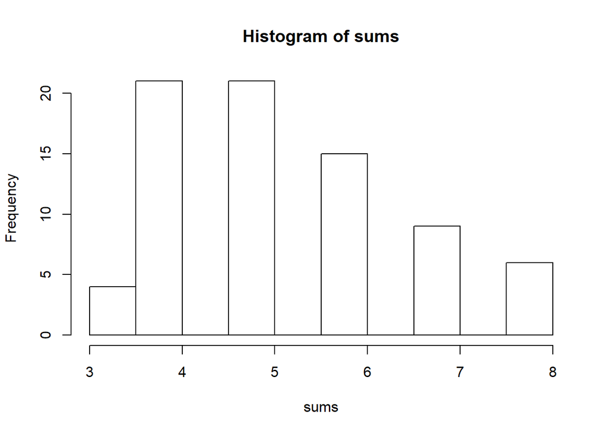

```r
rwl_live_pipo_t <- rwl_live_pipo
rwl_live_pipo_t[!is.na(rwl_live_pipo_t)] <- 1
rwl_live_pipo_t[is.na(rwl_live_pipo_t)] <- 0

sums <- t(rwl_live_pipo_t) %>% rowSums()
hist(sums)
```

```r
head(sums)
```

```
## 106B 107B 109B  10B 110B 115B
##    5    4    5    4    3    3
```

```r
summary(as.factor(sums))
```

```
##  3  4  5  6  7  8
##  4 21 21 15  9  6
```

```r
sums <- sums[sums>6]

rwl_live_pipo_gr6 <- rwl_live_pipo[,names(rwl_live_pipo) %in% names(sums)]
ncol(rwl_live_pipo_gr6)
```

```
## [1] 15
```

```r
rwl_live_pipo_gr6 <- rwl_live_pipo[,names(rwl_live_pipo) %in% names(sums)]
rwl_live_pipo_gr6_nochron <- rwl_live_pipo[,!(names(rwl_live_pipo) %in% names(sums))]
ncol(rwl_live_pipo_gr6_nochron)
```

```
## [1] 61
```

```r
ncol(rwl_live_pipo_gr6_nochron) + ncol(rwl_live_pipo_gr6) == ncol(rwl_live_pipo)
```

```
## [1] TRUE
```

### Save filtered set

```r
write.rwl(rwl_live_pipo_gr6, fname = "../../data/GrowthMortality/live_pipo_gr6.rwl")
```

```
## [1] "../../data/GrowthMortality/live_pipo_gr6.rwl"
```

```r
write.rwl(rwl_live_pipo_gr6_nochron, fname = "../../data/GrowthMortality/live_pipo_gr6_nochron.rwl")
```

```
## [1] "../../data/GrowthMortality/live_pipo_gr6_nochron.rwl"
```

## ABCO Take out trees with only a few years

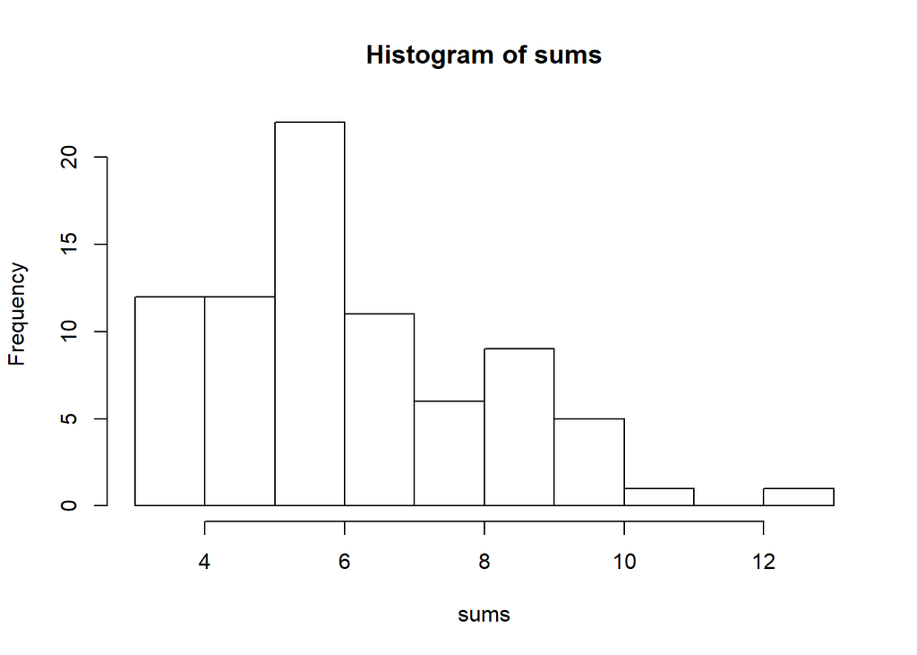

```r
rwl_live_abco_t <- rwl_live_abco
rwl_live_abco_t[!is.na(rwl_live_abco_t)] <- 1
rwl_live_abco_t[is.na(rwl_live_abco_t)] <- 0

sums <- t(rwl_live_abco_t) %>% rowSums()
hist(sums)
```

```r
head(sums)
```

```
## 100B 101B 102B 111B 117B 119B
##    8    5    6    5    7    6
```

```r
summary(as.factor(sums))
```

```
##  3  4  5  6  7  8  9 10 11 13
##  5  7 12 22 11  6  9  5  1  1
```

```r
sums <- sums[sums>6]

rwl_live_abco_gr6 <- rwl_live_abco[,names(rwl_live_abco) %in% names(sums)]
ncol(rwl_live_abco_gr6)
```

```
## [1] 33
```

```r
rwl_live_abco_gr6_nochron <- rwl_live_abco[,!(names(rwl_live_abco) %in% names(sums))]
ncol(rwl_live_abco_gr6_nochron) + ncol(rwl_live_abco_gr6) == ncol(rwl_live_abco)
```

```
## [1] TRUE
```

### Save filtered set

```r
write.rwl(rwl_live_abco_gr6, fname = "../../data/GrowthMortality/live_abco_gr6.rwl")
```

```
## [1] "../../data/GrowthMortality/live_abco_gr6.rwl"
```

```r
write.rwl(rwl_live_abco_gr6_nochron, fname = "../../data/GrowthMortality/live_abco_gr6_nochron.rwl")
```

```
## [1] "../../data/GrowthMortality/live_abco_gr6_nochron.rwl"
```

## Save filtered set of ABCO and PIPO together

```r
rwl_live_both_gr6 <- cbind(rwl_live_abco_gr6, rwl_live_pipo_gr6)
```

### Check

```r
rwl_live_both_gr6[1:2]
```

```
##            100B      117B
## 2004         NA        NA
## 2005         NA        NA
## 2006         NA        NA
## 2007         NA        NA
## 2008         NA        NA
## 2009 0.04000000        NA
## 2010 0.07333333 0.3933333
## 2011 0.03666667 0.6733333
## 2012 0.10333333 0.8533333
## 2013 0.15000000 0.4466667
## 2014 0.09000000 0.4400000
## 2015 0.05000000 0.5633333
## 2016 0.05333333 0.5200000
```

```r
rwl_live_abco_gr6[1:2]
```

```
##            100B      117B
## 2004         NA        NA
## 2005         NA        NA
## 2006         NA        NA
## 2007         NA        NA
## 2008         NA        NA
## 2009 0.04000000        NA
## 2010 0.07333333 0.3933333
## 2011 0.03666667 0.6733333
## 2012 0.10333333 0.8533333
## 2013 0.15000000 0.4466667
## 2014 0.09000000 0.4400000
## 2015 0.05000000 0.5633333
## 2016 0.05333333 0.5200000
```

```r
ncol(rwl_live_both_gr6)
```

```
## [1] 48
```

```r
rwl_live_both_gr6[47:48]
```

```
##            73B       75B
## 2004        NA        NA
## 2005        NA        NA
## 2006        NA        NA
## 2007        NA        NA
## 2008        NA        NA
## 2009        NA        NA
## 2010 0.3500000 0.5033333
## 2011 0.5833333 0.4966667
## 2012 0.6400000 0.5566667
## 2013 0.7300000 0.6933333
## 2014 0.5400000 0.5966667
## 2015 0.7833333 0.8433333
## 2016 0.6833333 0.6066667
```

```r
ncol(rwl_live_pipo_gr6)
```

```
## [1] 15
```

```r
rwl_live_pipo_gr6[13:14]
```

```
##            61B       73B
## 2004        NA        NA
## 2005        NA        NA
## 2006        NA        NA
## 2007        NA        NA
## 2008        NA        NA
## 2009 0.2200000        NA
## 2010 0.1933333 0.3500000
## 2011 0.1333333 0.5833333
## 2012 0.2000000 0.6400000
## 2013 0.1066667 0.7300000
## 2014 0.1066667 0.5400000
## 2015 0.1333333 0.7833333
## 2016 0.1033333 0.6833333
```

```r
write.rwl(rwl_live_both_gr6, fname = "../../data/GrowthMortality/live_both_gr6.rwl")
```

```
## [1] "../../data/GrowthMortality/live_both_gr6.rwl"
```

```r
rwl_live_both_gr6_nochron <- cbind(rwl_live_abco_gr6_nochron, rwl_live_pipo_gr6_nochron)
```

```r
write.rwl(rwl_live_both_gr6_nochron, fname = "../../data/GrowthMortality/live_both_gr6_nochron.rwl")
```

```
## [1] "../../data/GrowthMortality/live_both_gr6_nochron.rwl"
```

# Filter by size

## Calculate average and median diameter

```r
join <- join %>%
  rowwise() %>%
  mutate(dia_ave = mean(c(BAS_DIA_1_mm, BAS_DIA_2_mm))) %>%
  ungroup()
head(join %>% dplyr::select(tree, series, BAS_DIA_1_mm, BAS_DIA_2_mm, dia_ave) )
```

```
## # A tibble: 6 x 5
##   tree  series   BAS_DIA_1_mm BAS_DIA_2_mm dia_ave
##   <chr> <chr>           <dbl>        <dbl>   <dbl>
## 1 204B  204BR1BU          9            8.5    8.75
## 2 204B  204BR2            9            8.5    8.75
## 3 204B  204BR3BU          9            8.5    8.75
## 4 11    11BUR1            9.2          8.6    8.90
## 5 11    11BUR2            9.2          8.6    8.90
## 6 11    11BUR3            9.2          8.6    8.90
```

```r
quarters <- join %>%
  group_by(SPECIES) %>%
  summarize(quantile(na.omit(dia_ave), probs = .75))
quarters
```

```
## # A tibble: 3 x 2
##   SPECIES `quantile(na.omit(dia_ave), probs = 0.75)`
##   <chr>                                        <dbl>
## 1 ABCO                                          10.1
## 2 PIPO                                          10.6
## 3 <NA>                                          NA
```

## PIPO

```r
quarter_pipo <- quarters %>% filter(SPECIES == "PIPO")
quarter_pipo
```

```
## # A tibble: 1 x 2
##   SPECIES `quantile(na.omit(dia_ave), probs = 0.75)`
##   <chr>                                        <dbl>
## 1 PIPO                                          10.6
```

```r
big_pipo <- join %>% filter(SPECIES == "PIPO") %>% filter(dia_ave > unlist(quarter_pipo[2]))
nrow(big_pipo)/nrow(join %>% filter(SPECIES == "PIPO"))
```

```
## [1] 0.2489362
```

```r
rwl_live_pipo_big <- rwl_live_pipo[,names(rwl_live_pipo) %in% big_pipo$tree]
ncol(rwl_live_pipo_big)
```

```
## [1] 22
```

```r
rwl_live_pipo_big_nochron <- rwl_live_pipo[,!(names(rwl_live_pipo) %in% big_pipo$tree)]
ncol(rwl_live_pipo_big_nochron)
```

```
## [1] 54
```

```r
ncol(rwl_live_pipo_big_nochron) + ncol(rwl_live_pipo_big) == ncol(rwl_live_pipo)
```

```
## [1] TRUE
```

### PIPO Save filtered set

```r
write.rwl(rwl_live_pipo_big, fname = "../../data/GrowthMortality/live_pipo_big.rwl")
```

```
## [1] "../../data/GrowthMortality/live_pipo_big.rwl"
```

```r
write.rwl(rwl_live_pipo_big_nochron, fname = "../../data/GrowthMortality/live_pipo_big_nochron.rwl")
```

```
## [1] "../../data/GrowthMortality/live_pipo_big_nochron.rwl"
```

## ABCO

```r
quarter_abco <- quarters %>% filter(SPECIES == "ABCO")
quarter_abco
```

```
## # A tibble: 1 x 2
##   SPECIES `quantile(na.omit(dia_ave), probs = 0.75)`
##   <chr>                                        <dbl>
## 1 ABCO                                          10.1
```

```r
big_abco <- join %>% filter(SPECIES == "ABCO") %>% filter(dia_ave > unlist(quarter_abco[2]))
nrow(big_abco)/nrow(join %>% filter(SPECIES == "ABCO"))
```

```
## [1] 0.25
```

```r
rwl_live_abco_big <- rwl_live_abco[,names(rwl_live_abco) %in% big_abco$tree]
ncol(rwl_live_abco_big)
```

```
## [1] 20
```

```r
rwl_live_abco_big_nochron <- rwl_live_abco[,!(names(rwl_live_abco) %in% big_abco$tree)]
ncol(rwl_live_abco_big_nochron)
```

```
## [1] 59
```

```r
ncol(rwl_live_abco_big_nochron) + ncol(rwl_live_abco_big) == ncol(rwl_live_abco)
```

```
## [1] TRUE
```

### abco Save filtered set

```r
write.rwl(rwl_live_abco_big, fname = "../../data/GrowthMortality/live_abco_big.rwl")
```

```
## [1] "../../data/GrowthMortality/live_abco_big.rwl"
```

```r
write.rwl(rwl_live_abco_big_nochron, fname = "../../data/GrowthMortality/live_abco_big_nochron.rwl")
```

```
## [1] "../../data/GrowthMortality/live_abco_big_nochron.rwl"
```

## Save filtered set of ABCO and PIPO together

```r
rwl_live_both_big <- cbind(rwl_live_abco_big, rwl_live_pipo_big)
```

```r
write.rwl(rwl_live_both_big, fname = "../../data/GrowthMortality/live_both_big.rwl")
```

```
## [1] "../../data/GrowthMortality/live_both_big.rwl"
```

```r
rwl_live_both_big_nochron <- cbind(rwl_live_abco_big_nochron, rwl_live_pipo_big_nochron)
```

### Check

```r
rwl_live_both_big_nochron[1:2]
```

```
##            100B      101B
## 2004         NA        NA
## 2005         NA        NA
## 2006         NA        NA
## 2007         NA        NA
## 2008         NA        NA
## 2009 0.04000000        NA
## 2010 0.07333333        NA
## 2011 0.03666667        NA
## 2012 0.10333333 0.6966667
## 2013 0.15000000 0.7066667
## 2014 0.09000000 0.2466667
## 2015 0.05000000 0.1700000
## 2016 0.05333333 0.3366667
```

```r
rwl_live_abco_big_nochron[1:2]
```

```
##            100B      101B
## 2004         NA        NA
## 2005         NA        NA
## 2006         NA        NA
## 2007         NA        NA
## 2008         NA        NA
## 2009 0.04000000        NA
## 2010 0.07333333        NA
## 2011 0.03666667        NA
## 2012 0.10333333 0.6966667
## 2013 0.15000000 0.7066667
## 2014 0.09000000 0.2466667
## 2015 0.05000000 0.1700000
## 2016 0.05333333 0.3366667
```

```r
write.rwl(rwl_live_both_big_nochron, fname = "../../data/GrowthMortality/live_both_big_nochron.rwl")
```

```
## [1] "../../data/GrowthMortality/live_both_big_nochron.rwl"
```

# MAJOR THINGS I NEED TO DO:

Seedlings needing checking: 12, 155, 26, 98, 63B, 163B, 159B, 195B, 205B

1. Which 12 is the real 12?
2. Check why Seedling 155 was thrown out - it’s on board 32 but no data
3. Look for seedling 26 on board 39 - it doesn’t have measurements in the original board 39 data
4. seedlings 98, 63B, and 163B - they’re not listed as having a board, so look for it in the thrown out pile
5. Seedling 159B - not listed as having a board
6. Look for seedling 195B - on board 28 but not in data
7. 205B - missing
8. See which trees do and don’t have mates
9. APPLY THESE CHANGES TO THE rwl DATA FRAME
10. ASK JODI WHETHER DIAMETER CHANGES AS TREES AGE AFTER DEATH

# Just for funsies, compare growth in dead trees vs. live trees, roughly

## Tidy growth data

```r
join <- gather(join, key = "YEAR", value = "GROWTH_mm", 5:17)
```

## Compare

```r
prelim <- join %>%
  filter(!is.na(GROWTH_mm)) %>%
  filter(thrown_out == 0) %>%
  filter(YEAR %in% c(2014, 2015, 2016)) %>%
  mutate(rel_growth = GROWTH_mm/BAS_DIA_1_mm) %>%
  group_by(tree, SPECIES, DEAD_ALIVE) %>%
  summarize(rel_growth = mean(rel_growth), growth_mm = mean(GROWTH_mm), growth_vert = mean(na.omit(as.numeric(paste(LAST_YR_GR_cm))/HEIGHT)))
```

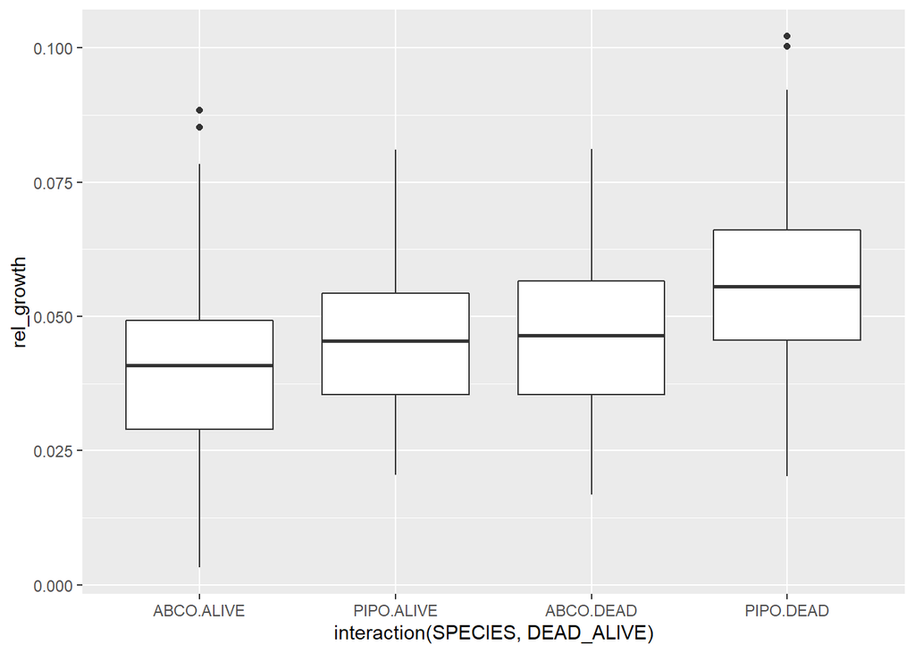

```r
ggplot(prelim)+
  geom_boxplot(aes(x = interaction(SPECIES, DEAD_ALIVE), y= rel_growth))
```

```r
anova(lm(rel_growth ~ DEAD_ALIVE, data = prelim %>% filter(SPECIES == "PIPO")))
```

```
## Analysis of Variance Table
##
## Response: rel_growth
##             Df   Sum Sq   Mean Sq F value    Pr(>F)
## DEAD_ALIVE   1 0.005823 0.0058230  26.793 7.114e-07 ***
## Residuals  151 0.032817 0.0002173
## ---
## Signif. codes:  0 '***' 0.001 '**' 0.01 '*' 0.05 '.' 0.1 ' ' 1
```

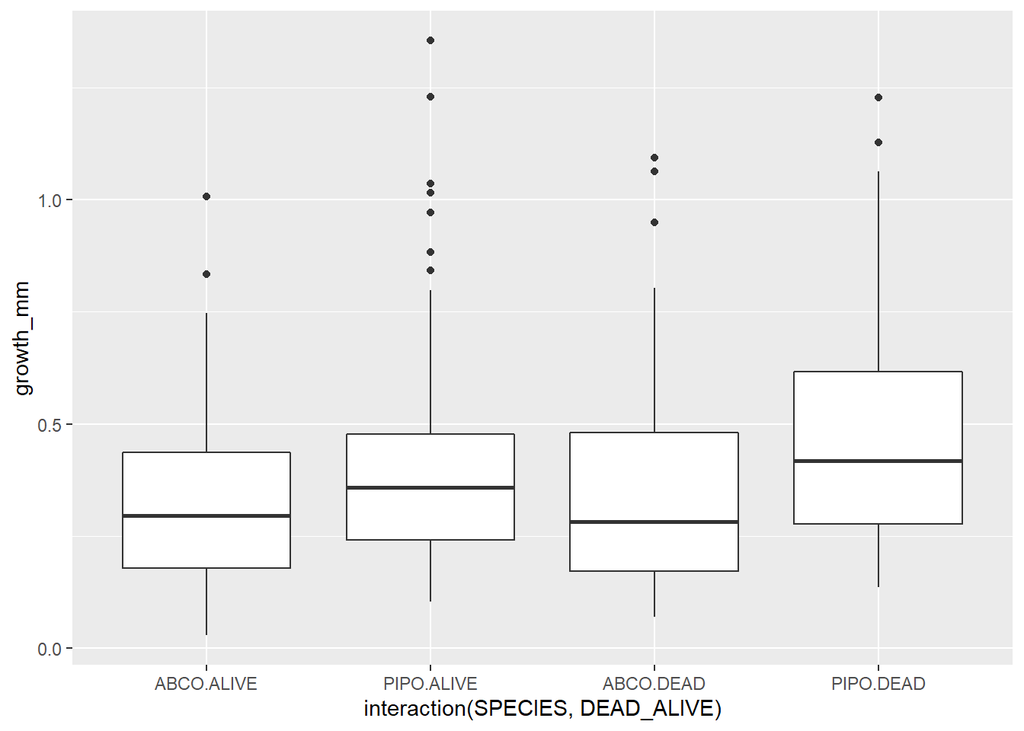

```r
ggplot(prelim)+
  geom_boxplot(aes(x = interaction(SPECIES, DEAD_ALIVE), y= growth_mm))
```

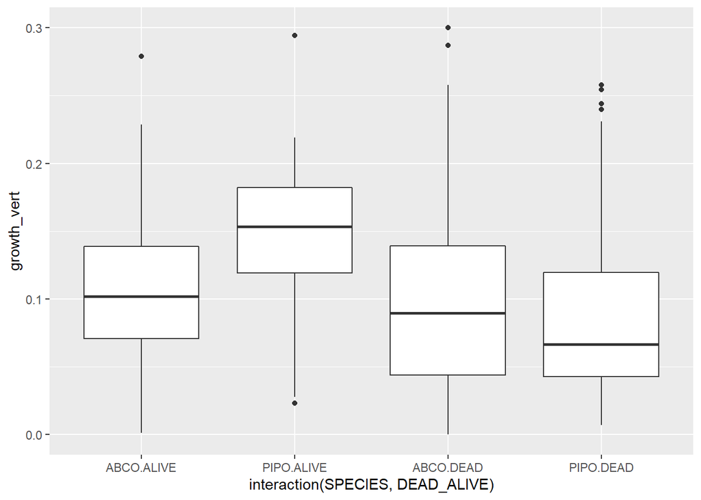

```r
ggplot(prelim)+
  geom_boxplot(aes(x = interaction(SPECIES, DEAD_ALIVE), y= growth_vert))
```